# Exercise 4

Team members: Agata Kaczmarek (4734079), Mateusz Stączek (4734410)

```python
import matplotlib.pyplot as plt
import torch
import torch.nn as nn
import pandas as pd
import numpy as np
np.random.seed(42)
import torch.nn.functional as F
from matplotlib.patches import Ellipse
import seaborn as sns
```

## 1. Noise-free data

### 1.1 - Implement simulate_sir_simple()

Implement a function simulate_sir_simple(lam, mu, I_0, T), that takes the specified parameters and simulates the epidemy using the Euler forward scheme up to day $T$. The vector of hidden parameters is therefore $Y = [λ, µ, I_0]$.

```python
def simulate_sir_sample(lam, mu, I_0, T):
    """

    input: I_0 is between 0 and 1, this is the fraction: [I(t=0)]

    takes the specified parameters and simulates the epidemy using the Euler forward scheme up to day T
    vector of hidden parameters: Y=[lam, mu, I_0]
    return th sequence ofw observations: X=[delta_S(1), delta_R(1), delta_S(2), ...., delta_S(T), delta_R(T)]
    also for debugging and visualization: #used only for testing, nothing more
    return sequence of corresponding ODE variables: C=[(S(1), I(1), R(1)),
                                                       (S(2), I(2), R(2)),
                                                       ...
                                                       (S(T), I(T), R(T))]
    """

    S = [1 for _ in range(T+1)]
    R = [0 for _ in range(T+1)]
    I = [0 for _ in range(T+1)]
    C = [0 for _ in range(T+1)]
    X = [0 for _ in range(2*T)]

    S[0] = 1-I_0
    I[0] = I_0

    for i in range(T):
        S[i+1] = S[i]-lam*I[i]*S[i]
        I[i+1] = I[i]+lam*I[i]*S[i]-mu*I[i]
        R[i+1] = R[i]+mu*I[i]
        X[2*i] = S[i]-S[i+1]
        X[2*i+1] = R[i+1]-R[i]
    C = [S,I,R]
    return X, C
```

```python
X_testowy, C_testowy = simulate_sir_sample(lam=0.2, mu=0.5, I_0=0.3, T=3)
```

```python
X_testowy
```

```
[0.04200000000000004,
 0.15,
 0.025267200000000045,
 0.096,
 0.015345947000832028,
 0.06063360000000001]
```

```python
C_testowy
```

```
[[0.7, 0.6579999999999999, 0.6327327999999999, 0.6173868529991678],
 [0.3, 0.19199999999999998, 0.12126719999999998, 0.07597954700083198],
 [0, 0.15, 0.246, 0.3066336]]
```

Comment:

The solution is also correct, but differs from the sample one - we decided to input $I_0$ as a fraction, so in the implementation we operate on fractions, and do not divide by N separately.

### 1.2 - Run simulations

Run the simulation with T = 100 and visualize the results. Determine suitable ranges of the parameters such that the first 100 days exhibit interesting and diverse dynamics. This is important, because when not much happens between day 1 and day T, there will be insufficient information to solve the inverse problem. Use the results of these experiments to define the simulation prior $p^{sim}(Y)=p^{sim}(\lambda)*p^{sim}(\mu)*p^{sim}(I_0)$.

```python
X_data, C_data = simulate_sir_sample(lam=0.18, mu=0.05, I_0=0.05, T=100)
```

```python
def plot_simulation_all_combinations(lam_list, mu_list, I_0_list):
    for lam in lam_list:
        for mu in mu_list:
            for I_0 in I_0_list:
                X_data, C_data=simulate_sir_sample(lam, mu, I_0, 100)
                plt.plot(C_data[0], c="blue", label="S")
                plt.plot(C_data[1], c="red", label="I")
                plt.plot(C_data[2], c="green", label="R")
                plt.title(f"Simulation results: lam: {lam}, mu: {mu}, I_0: {I_0}")
                plt.xlabel("Time")
                plt.ylabel("Fraction of population")
                plt.legend(loc="upper right")
                print(f"Simulation results: lam: {lam}, mu: {mu}, I_0: {I_0}")
                plt.show()

def plot_simulation_tuples(lam_list, mu_list, I_0_list):
    for lam, mu, I_0 in zip(lam_list, mu_list, I_0_list):
        X_data, C_data=simulate_sir_sample(lam, mu, I_0, 100)
        plt.plot(C_data[0], c="blue", label="S")
        plt.plot(C_data[1], c="red", label="I")
        plt.plot(C_data[2], c="green", label="R")
        plt.title(f"Simulation results: lam: {lam}, mu: {mu}, I_0: {I_0}")
        plt.xlabel("Time")
        plt.ylabel("Fraction of population")
        plt.legend(loc="upper right")
        print(f"Simulation results: lam: {lam}, mu: {mu}, I_0: {I_0}")
        plt.show()
```

```
Simulation results: lam: 0.18, mu: 0.05, I_0: 0.05
```

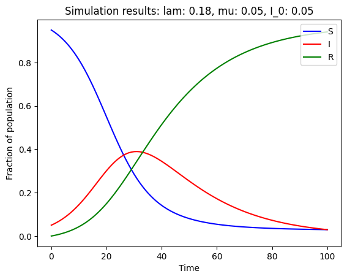

```python
# best: lam: 0.18, mu: 0.05, I_0: 0.05

lam_list=[0.18]
mu_list=[0.05]
I_0_list=[0.05]

plot_simulation_all_combinations(lam_list, mu_list, I_0_list)
```

```python
def generate_y(lam=0.18, mu=0.05, I_0=0.05):
    lam_gen=np.random.normal(lam, 0.04)
    mu_gen=np.random.normal(mu, 0.01)
    I_0_gen=np.random.normal(I_0, 0.01)

    y = [lam_gen,mu_gen,I_0_gen]
    return y
```

```python
generate_y()
```

```
[0.1998685661204493, 0.04861735698828815, 0.056476885381006925]
```

```
Simulation results: lam: 0.241, mu: 0.048, I_0: 0.048
```

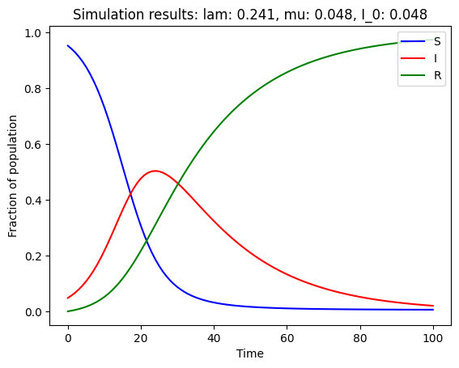

```
Simulation results: lam: 0.243, mu: 0.058, I_0: 0.045
```

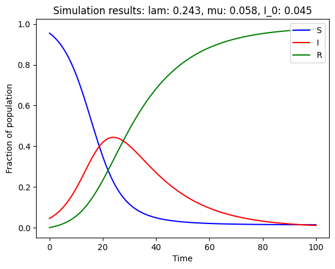

```
Simulation results: lam: 0.202, mu: 0.045, I_0: 0.045
```

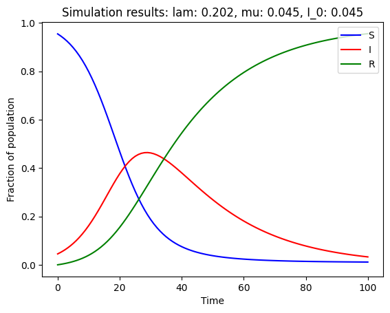

```
Simulation results: lam: 0.19, mu: 0.031, I_0: 0.033
```

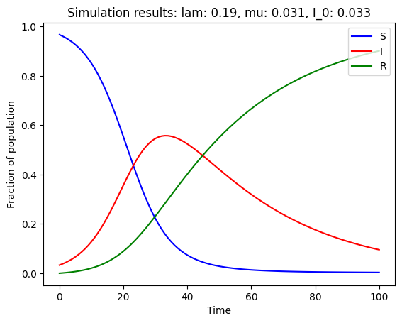

```
Simulation results: lam: 0.158, mu: 0.04, I_0: 0.053
```

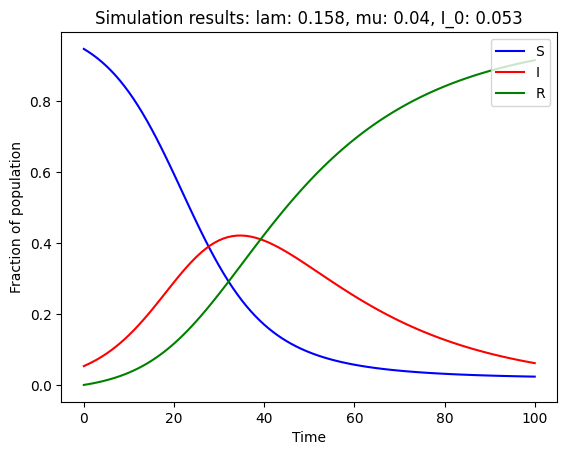

```python
# sampled from the prior distribution

sampled_y = [generate_y() for _ in range(5)]

lam_list = [np.round(y[0], 3) for y in sampled_y]
mu_list = [np.round(y[1], 3) for y in sampled_y]
I_0_list = [np.round(y[2], 3) for y in sampled_y]

plot_simulation_tuples(lam_list, mu_list, I_0_list)
```

Comment

Our code is also correct, we run simulations for various settings and chose the one that seemed to be the most suitable for the task. The ranges of the parameters seems to be similar. We did not write long comments, describing why we chose the ranges, we will consider writing longer comments during the next task.

### 1.3 Define feed-forward network

Define a feed-forward or convolutional network Φ that predicts parameters directly from observations, $\hat{Y} = Φ(X). Train this network with the squared loss using a training set generated by the simulation and prior distribution, and evaluate it by a simulated test set. Visualize the accuracy as a function of hyperparameter choices (especially the sizes of the network and training set) in suitable diagrams. Note that this network disregards potential uncertainty and ambiguity of the inverse problem - it just returns a point estimate, i.e. a single vector of plausible parameters Yb for every given X. For simplicity, the length of the sequence X (i.e. the stopping time T) shall be constant for all training and testing runs.

```python
class FeedForward_Task_1_3(nn.Module):
    def __init__(self, input_size, hidden_size, number_of_layers, output_size):
        super(FeedForward_Task_1_3, self).__init__()
        self.input_size = input_size
        self.hidden_size = hidden_size
        self.output_size = output_size

        self.layers = nn.ModuleList([nn.Linear(self.input_size, self.hidden_size)])
        for _ in range(number_of_layers - 1):
            self.layers.append(nn.Linear(self.hidden_size, self.hidden_size))
        self.last_layer = nn.Linear(self.hidden_size, self.output_size)

    def forward(self, x):
        for i in range(len(self.layers)):
            x = self.layers[i](x)
            x = F.relu(x)
        x = self.last_layer(x)
        return x
```

```python
# a simple training of a feedforward network with squared loss

def train_simple_feedforward(model,
                            X_train, X_test,
                            y_train, y_test,
                            n_epochs, batch_size,
                            learning_rate=0.001,
                            size_of_the_training_set=-1):
    """
    Args:
        model (nn.Module): the model to train
        X_train (np.ndarray): the training data (observations)
        X_test (np.ndarray): the test data (observations)
        y_train (np.ndarray): the training data outputs (simulation params)
        y_test (np.ndarray): the test data outputs (simulation params)
        n_epochs (int): the number of training epochs
        batch_size (int): the batch size
        learning_rate (float): the learning rate
        size_of_the_training_set (int): subset of the training set to use (default: -1, i.e. use the whole training set)
    """

    loss_function = nn.MSELoss()
    optimizer = torch.optim.Adam(model.parameters(), lr=learning_rate)

    train_losses = []
    test_losses = []

    X_train = X_train[:size_of_the_training_set]
    y_train = y_train[:size_of_the_training_set]

    X_train = torch.from_numpy(X_train).float()
    y_train = torch.from_numpy(y_train).float()
    X_test = torch.from_numpy(X_test).float()
    y_test = torch.from_numpy(y_test).float()

    # loss before training
    with torch.no_grad():
        loss = loss_function(model(X_train), y_train)
        train_losses.append(loss.item())
        loss = loss_function(model(X_test), y_test)
        test_losses.append(loss.item())
    print(f"Epoch 0/{n_epochs}: train_loss={train_losses[-1]:.4f}, test_loss={test_losses[-1]:.4f}")

    # training
    for epoch in range(n_epochs):
        train_loss = 0
        test_loss = 0
        for i in range(0, len(X_train), batch_size):
            data = X_train[i:i+batch_size]
            y_data = y_train[i:i+batch_size]
            optimizer.zero_grad()
            loss = loss_function(model(data), y_data)
            loss.backward()
            optimizer.step()
            train_loss += loss.item() * len(data)
        train_loss /= len(X_train)
        train_losses.append(train_loss)

        with torch.no_grad():
            for i in range(0, len(X_test), batch_size):
                data = X_test[i:i+batch_size]
                y_data = y_test[i:i+batch_size]
                loss = loss_function(model(data), y_data)
                test_loss += loss.item() * len(data)
            test_loss /= len(X_test)
            test_losses.append(test_loss)

        if (epoch+1) % (n_epochs//10+1) == 0 or epoch == n_epochs-1:
            print(f"Epoch {epoch+1}/{n_epochs}: train_loss={train_loss:.4f}, test_loss={test_loss:.4f}")
    df = pd.DataFrame({'train': train_losses, 'test': test_losses, 'epoch': list(range(n_epochs+1))})
    return df
```

```
Generate data and train feed forward network.
```

```python
N = 1000

# constant length of epidemy
T = 100

y = np.array([generate_y() for _ in range(N)])
X = np.array([simulate_sir_sample(y[i][0], y[i][1], y[i][2], T)[0] for i in range(len(y))])

train_test_split = 0.8

X_train = X[:int(train_test_split*len(X))]
X_test = X[int(train_test_split*len(X)):]
y_train = y[:int(train_test_split*len(y))]
y_test = y[int(train_test_split*len(y)):]
```

```python
feedforward_model_best = FeedForward_Task_1_3(input_size=200,
                                         hidden_size=32,
                                         number_of_layers=2,
                                         output_size=3)


df = train_simple_feedforward(model=feedforward_model_best,
                        X_train=X_train, X_test=X_test, y_train=y_train, y_test=y_test,
                        n_epochs=20, batch_size=64)
```

[output not shown]

```
Evaluate network sizes - hidden size, number of layers
```

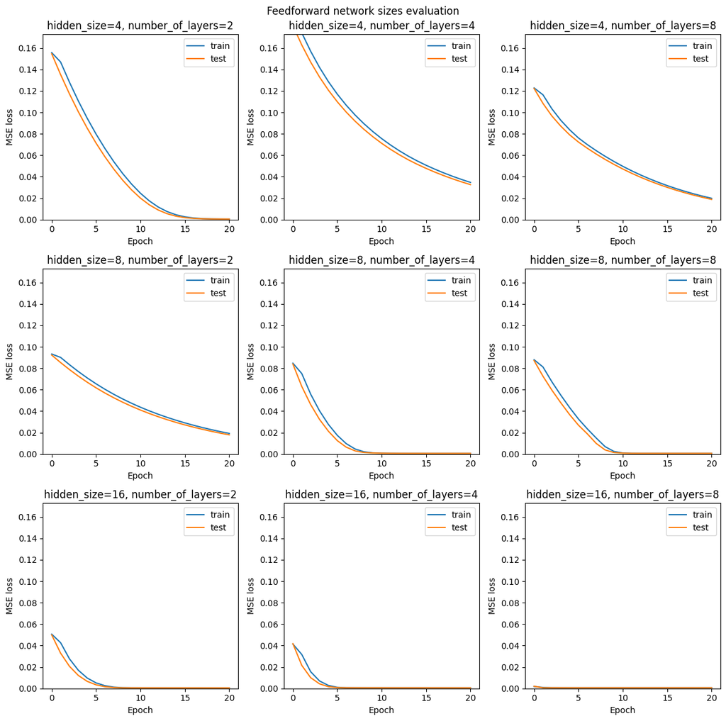

```python
hidden_sizes = [4, 8, 16]
numbers_of_layers = [2, 4, 8]
training_params = {'n_epochs': 20, 'batch_size': 64, 'learning_rate': 0.001}

fig, axs = plt.subplots(3, 3, figsize=(12, 12))
y_lim_max = -np.inf
for i, hidden_size in enumerate(hidden_sizes):
    for j, number_of_layers in enumerate(numbers_of_layers):
        feedforward_model = FeedForward_Task_1_3(input_size=200,
                                                 hidden_size=hidden_size,
                                                 number_of_layers=number_of_layers,
                                                 output_size=3)
        df = train_simple_feedforward(model=feedforward_model,
                                X_train=X_train, X_test=X_test, y_train=y_train, y_test=y_test,
                                **training_params)
        axs[i, j].plot(df['epoch'], df['train'], label='train')
        axs[i, j].plot(df['epoch'], df['test'], label='test')
        axs[i, j].set_title(f"hidden_size={hidden_size}, number_of_layers={number_of_layers}")
        axs[i, j].legend()
        axs[i, j].set_xlabel('Epoch')
        axs[i, j].set_ylabel('MSE loss')
        y_lim_max = max(y_lim_max, max(df['train'][2:].max(), df['test'][2:].max()))
for i, hidden_size in enumerate(hidden_sizes):
    for j, number_of_layers in enumerate(numbers_of_layers):
        axs[i, j].set_ylim([0, y_lim_max*1.1])
fig.suptitle('Feedforward network sizes evaluation')
fig.tight_layout()
plt.show()
```

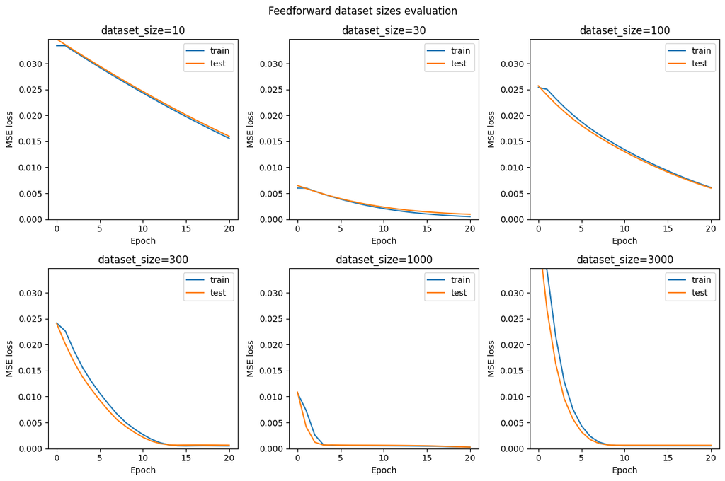

```python
# evaluate dataset sizes
dataset_sizes = [10, 30, 100, 300, 1000, 3000]
training_params = {'n_epochs': 20, 'batch_size': 64, 'learning_rate': 0.001}

fig, axs = plt.subplots(2, 3, figsize=(12, 8))
y_lim_max = -np.inf
for i, dataset_size in enumerate(dataset_sizes):
    feedforward_model = FeedForward_Task_1_3(input_size=200,
                                                hidden_size=16,
                                                number_of_layers=4,
                                                output_size=3)
    df = train_simple_feedforward(model=feedforward_model,
                            X_train=X_train, X_test=X_test, y_train=y_train, y_test=y_test,
                            **training_params, size_of_the_training_set=dataset_size)
    axs[i//3, i%3].plot(df['epoch'], df['train'], label='train')
    axs[i//3, i%3].plot(df['epoch'], df['test'], label='test')
    axs[i//3, i%3].set_title(f"dataset_size={dataset_size}")
    axs[i//3, i%3].set_xlabel('Epoch')
    axs[i//3, i%3].set_ylabel('MSE loss')
    axs[i//3, i%3].legend()
    y_lim_max = max(y_lim_max, max(df['train'][3:].max(), df['test'][3:].max()))
for i, dataset_size in enumerate(dataset_sizes):
    axs[i//3, i%3].set_ylim([0, y_lim_max*1.1])
fig.suptitle('Feedforward dataset sizes evaluation')
fig.tight_layout()
plt.show()
```

[output not shown]

Comment

- in the sample solution authors decided to use convolutional neural network and here we decided to use feed forward network. This makes a difference and we cannot compare the results directly.
- however, in our solution we did all steps analogously to the ones in sample solution: we created the network, generated dataset, trained the network on the dataset, judged the effects and later compared various hyperparametes settings.
- solution is therefore a valid alternative of those steps.

### 1.4 Modifications for the network

Modify the network Φ so that it can serve as a summary network (feature detector) h(X) for a conditional normalizing flow. That is, remove the network's last layer and possibly fine-tune its hyperparameters. Implement a conditional RealNVP that estimates the posterior $p(Y|h(X))$. Train the two networks jointly by minimizing the NLL loss over the training set. Visualize the resulting posteriors, along with ground-truth values Y∗, for some representative test instances.

```python
class FeedForward_Task_1_3_without_last_layer(nn.Module):
    def __init__(self, whole_model):
        super(FeedForward_Task_1_3_without_last_layer, self).__init__()
        # whole_model has .last_layer as last layer, and .layers for all other layers
        self.layers = whole_model.layers
        self.output_size = whole_model.hidden_size

    def forward(self, x):
        for i in range(len(self.layers)):
            x = self.layers[i](x)
            if i < len(self.layers)-1:
                x = F.relu(x)
        return x
```

```python
# Conditional Real NVP copied from assignment 3
# X and Y are switched in the task description of assignment 4 !!!

class CouplingBlockConditional(nn.Module):
    def __init__(self, input_size, hidden_size, condition_size):
        super(CouplingBlockConditional, self).__init__()

        # d_tilde is size of what will be transformed
        self.input_size = input_size
        self.hidden_size = hidden_size
        self.condition_size = condition_size
        self.d_tilde = input_size // 2


        # 2 hidden layers with ReLU activation and linear output layer. exp and tanh are applied later
        self.scale_network = nn.Sequential(
            nn.Linear(self.d_tilde + self.condition_size, self.hidden_size),
            nn.ReLU(),
            nn.Linear(self.hidden_size, self.hidden_size),
            nn.ReLU(),
            nn.Linear(self.hidden_size, self.d_tilde),
        )

        # 2 hidden layers with ReLU activation and linear output layer
        self.translation_network = nn.Sequential(
            nn.Linear(self.d_tilde + self.condition_size, self.hidden_size),
            nn.ReLU(),
            nn.Linear(self.hidden_size, self.hidden_size),
            nn.ReLU(),
            nn.Linear(self.hidden_size, self.d_tilde),
        )

    def forward(self, x, y):
        x1 = x[:, :self.d_tilde]
        x2 = x[:, self.d_tilde:]

        z1 = x1

        x1_y = torch.cat([x1, y], dim=1)

        s = self.scale_network(x1_y)
        t = self.translation_network(x1_y)
        z2 = torch.exp(torch.tanh(s)) * x2 + t

        z = torch.cat([z1, z2], dim=1)

        log_det_jacobian = torch.sum(torch.tanh(s), dim=1)

        return z, log_det_jacobian

    def inverse(self, z, y):
        z1 = z[:, :self.d_tilde]
        z2 = z[:, self.d_tilde:]

        x1 = z1

        x1_y = torch.cat([z1, y], dim=1)
        s = self.scale_network(x1_y)
        t = self.translation_network(x1_y)

        x2 = (z2 - t) * torch.exp(-1 * torch.tanh(s))

        x = torch.cat([x1, x2], dim=1)

        return x

# below, inputs are called X and conditions are called Y
class ConditionalRealNVP(nn.Module):
    def __init__(self, input_size, hidden_size, blocks, condition_size):
        super(ConditionalRealNVP, self).__init__()
        self.input_size = input_size
        self.hidden_size = hidden_size
        self.blocks = blocks
        self.condition_size = condition_size

        self.layers = nn.ModuleList([CouplingBlockConditional(self.input_size, self.hidden_size, self.condition_size)
                                     for _ in range(self.blocks)])

        self.orthonormal_matrices = []
        self.orthonormal_matrices_T = []
        for i in range(self.blocks-1):
            matrix = self._get_orthonormal_matrix(self.input_size)
            self.orthonormal_matrices.append(matrix)
            self.orthonormal_matrices_T.append(torch.transpose(matrix, 0, 1))

    def _get_orthonormal_matrix(self, size):
        Q, _ = torch.linalg.qr(torch.randn(size, size))
        return nn.Parameter(Q, requires_grad=False)

    def encoder(self, x, y_conditions):
        log_det_jacobian_sum = 0
        for i in range(self.blocks):
            x, log_det_jacobian = self.layers[i](x, y_conditions)
            log_det_jacobian_sum += log_det_jacobian
            if i < self.blocks - 1:
                x = torch.matmul(x, self.orthonormal_matrices[i])
        return x, log_det_jacobian_sum

    def decoder(self, z, y_conditions):
        for i in range(self.blocks - 1, -1, -1):
            if i < self.blocks - 1:
                z = torch.matmul(z, self.orthonormal_matrices_T[i])
            z = self.layers[i].inverse(z, y_conditions)
        return z

    def forward(self, x, y_conditions):
        z, log_det_jacobian_sum = self.encoder(x, y_conditions)
        return z, log_det_jacobian_sum

    def sample(self, num_samples, y_conditions):
        y_conditions = torch.from_numpy(y_conditions).float()
        outputs = []
        for y_condition in y_conditions:
            z = torch.randn(num_samples, self.input_size)
            y_repeated = y_condition.repeat(num_samples, 1)
            samples = self.decoder(z, y_repeated)
            outputs.append(samples)
        outputs = torch.cat(outputs, dim=0)
        return outputs
```

```python
# training of real NVP with another model used as summary network

def custom_negative_log_likelihood_loss(model_outputs, log_det_jacobian_sum):
    return torch.mean(torch.sum(0.5 * torch.pow(model_outputs, 2), dim=1) - log_det_jacobian_sum)

def train_jointly_summary_and_inn(model_summary,
                                  model_realnvp,
                                  X_train, X_test,
                                  y_train, y_test,
                                  n_epochs, batch_size,
                                  learning_rate=0.001,
                                  size_of_the_training_set=-1,
                                  loss_function=custom_negative_log_likelihood_loss):
    """
    Args:
        model_summary (nn.Module): a model which extracts features from Y and puts as conditions to realNVP
        model_realnvp (nn.Module): a RealNVP model which returns z and log_det_jacobian_sum
        X_train (np.ndarray): the training data                 // <- assignment 4 - Ys
        X_test (np.ndarray): the test data                      // <- assignment 4 - Ys
        y_train (np.ndarray): the training data conditions      // <- assignment 4 - Xs
        y_test (np.ndarray): the test data conditions           // <- assignment 4 - Xs
        n_epochs (int): the number of training epochs
        batch_size (int): the batch size
        learning_rate (float): the learning rate
        size_of_the_training_set (int): subset of the training set to use (default: -1, i.e. use the whole training set)
        loss_function (function): the loss function to use (default: custom_negative_log_likelihood_loss)
    """

    def compute_loss(X, y, model_summary=model_summary, model_realnvp=model_realnvp,
                     loss_function=loss_function):
        y_transformed = model_summary(y)
        z, log_det_jacobian_sum = model_realnvp(X, y_transformed)
        loss = loss_function(z, log_det_jacobian_sum)
        return loss

    optimizer = torch.optim.Adam(list(model_summary.parameters()) + list(model_realnvp.parameters()), lr=learning_rate)

    train_losses = []
    test_losses = []

    X_train = X_train[:size_of_the_training_set]
    y_train = y_train[:size_of_the_training_set]

    X_train = torch.from_numpy(X_train).float()
    y_train = torch.from_numpy(y_train).float()
    X_test = torch.from_numpy(X_test).float()
    y_test = torch.from_numpy(y_test).float()

    # loss before training
    with torch.no_grad():
        loss = compute_loss(X_train, y_train)
        train_losses.append(loss.item())
        loss = compute_loss(X_test, y_test)
        test_losses.append(loss.item())
    print(f"Epoch 0/{n_epochs}: train_loss={train_losses[-1]:.4f}, test_loss={test_losses[-1]:.4f}")

    # training
    for epoch in range(n_epochs):
        train_loss = 0
        test_loss = 0
        for i in range(0, len(X_train), batch_size):
            data = X_train[i:i+batch_size]
            y_data = y_train[i:i+batch_size]
            optimizer.zero_grad()
            loss = compute_loss(data, y_data)
            loss.backward()
            optimizer.step()
            train_loss += loss.item() * len(data)
        train_loss /= len(X_train)
        train_losses.append(train_loss)

        with torch.no_grad():
            for i in range(0, len(X_test), batch_size):
                data = X_test[i:i+batch_size]
                y_data = y_test[i:i+batch_size]
                loss = compute_loss(data, y_data)
                test_loss += loss.item() * len(data)
            test_loss /= len(X_test)
            test_losses.append(test_loss)

        if (epoch+1) % (n_epochs//10+1) == 0 or epoch == n_epochs-1:
            print(f"Epoch {epoch+1}/{n_epochs}: train_loss={train_loss:.4f}, test_loss={test_loss:.4f}")
    df = pd.DataFrame({'train': train_losses, 'test': test_losses, 'epoch': list(range(n_epochs+1))})
    return df
```

```
Joint training of summary network and conditional normalizing flow.
```

```python
feature_extractor = FeedForward_Task_1_3_without_last_layer(feedforward_model_best)

print("Number of features in the extracted representation:", feature_extractor.output_size)

model_realnvp = ConditionalRealNVP(input_size=3, hidden_size=64, blocks=4,
                                   condition_size=feature_extractor.output_size)
```

```
Number of features in the extracted representation: 32
```

```python
df = train_jointly_summary_and_inn(model_summary=feature_extractor,
                              model_realnvp=model_realnvp,
                              X_train = y_train, # <- in assignment 3, X were data
                              X_test = y_test,  # <- in assignment 3, X were data
                              y_train = X_train, # <- in assignment 3, Y were conditions
                              y_test = X_test,  # <- in assignment 3, Y were conditions
                              n_epochs=100,
                              batch_size=64)
```

[output not shown]

```
Visualized posteriors for the first test instances are below.
```

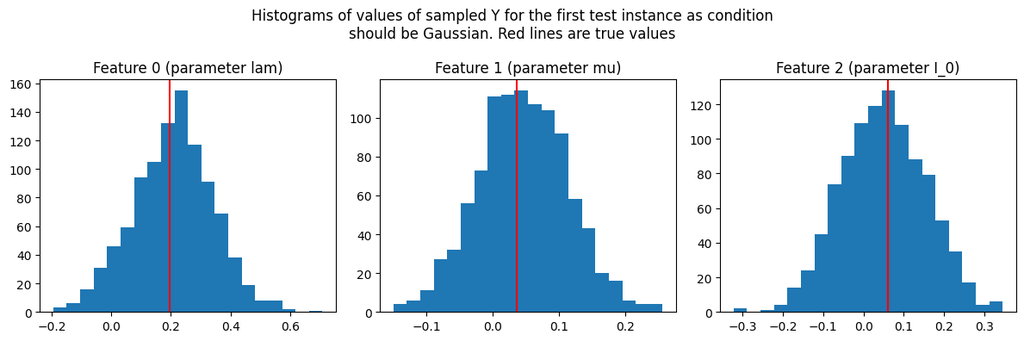

```python
y_base = np.array([y_test[0]])
y_feature_names = ['lam', 'mu', 'I_0']
X_base = np.array([X_test[0]])

with torch.no_grad():
    X_base_transformed = feature_extractor(torch.from_numpy(X_base).float())

y_samples = model_realnvp.sample(1000, X_base_transformed.detach().numpy()).detach().numpy()
# plot histograms of each of the 3 features of y_samples
fig, axs = plt.subplots(1, 3, figsize=(12, 4))
for i in range(3):
    axs[i].hist(y_samples[:, i], bins=20)
    axs[i].set_title(f"Feature {i} (parameter {y_feature_names[i]})")
    axs[i].axvline(y_base[0, i], color='red')
fig.suptitle("Histograms of values of sampled Y for the first test instance as condition\nshould be Gaussian. Red lines are true values")
fig.tight_layout()
plt.show()
```

```
Comment:
- sampled Ys are centered at the correct values
- the variance is not as small as expected. Instead, they are quite large and often exceed the range of the prior.

This is unfortunate, especially that Ys are often sampled from the negative range which makes no sense in the context of the problem. This will cause later problems.
```

Comment - different

### 1.5

Determine the quality of your model in terms of posterior calibration for both the marginal distributions of the individual parameters λ*hat, µ_hat, and I_0_hat, and the joint distribution of Y_hat via its energy $E(Y ) = − log p(Y|h(X))$. . To this end, for multiple fixed Xi, create samples ${Y_k hat ~ p(Y|h(X_i))*{k=1}}^M$ of parameter estimates from the posterior, and use both the histogram and the empirical CDF methods to check calibration.

```python
def evaluate_calibration_single(model_summary, model_realnvp, X_test, y_test, M=1000, column_names=["lam", "mu", "I_0"]):
    """
    Args:
        model_summary (nn.Module): a model which extracts features from Y and puts as conditions to realNVP
        model_realnvp (nn.Module): a RealNVP model which returns z and log_det_jacobian_sum
        X_test (np.ndarray): the test data simulation outcome
        y_test (np.ndarray): the test data simulation parameters
        M (int): the number of samples to generate for each test set sample
        column_names (list): the names of the columns of y_test
    """
    y_test = torch.from_numpy(y_test).float()
    X_test = torch.from_numpy(X_test).float()
    y_positions_in_sorted = np.zeros_like(y_test)
    with torch.no_grad():
        X_transformed = model_summary(X_test)
        for i, row in enumerate(X_transformed):
            row = torch.unsqueeze(row, 0).numpy()
            samples = model_realnvp.sample(M, row)
            for col_id in range(y_test.shape[1]):
                # find at which position will y_test[i, col_id] be in a sorted array.
                # When appended to the list of samples, it is at position M
                for_sorting = torch.cat([samples[:, col_id], torch.unsqueeze(y_test[i, col_id], 0)])
                _, indices = torch.sort(for_sorting)
                y_positions_in_sorted[i, col_id] = np.where(indices.numpy() == M)[0][0] / M
    for col_id in range(y_test.shape[1]):
        # plot histogram
        fig, axs = plt.subplots(1,2, figsize=(10, 5))
        axs[0].hist(y_positions_in_sorted[:, col_id], bins=25)
        axs[0].set_title(f"Calibration of column {column_names[col_id]}")
        axs[0].set_xlabel("Position of the true value in the sorted samples")
        axs[0].set_ylabel("Frequency")
        # plot empirical cdf
        should_be_t = np.linspace(0, 1, 100)
        cdf_empirical = np.zeros_like(should_be_t)
        for i, t in enumerate(should_be_t):
            cdf_empirical[i] = np.mean(y_positions_in_sorted[:, col_id] <= t)
        r_t = cdf_empirical - should_be_t
        axs[1].plot(should_be_t, r_t)
        axs[1].set_title(f"r(t) for column {column_names[col_id]}")
        axs[1].set_xlabel("t")
        axs[1].set_ylabel("r(t)")
        axs[1].axhline(0, color='black', linestyle='--')
        axs[1].add_patch(Ellipse((0.5, 0), 1, 2, color='red', fill=False))
        axs[1].set_ylim([-1, 1])
        plt.show()
```

```python
def compute_energy(model_realnvp, y_sample, X_transformed):
    """
    Args:
        model_summary (nn.Module): a model which extracts features from Y and puts as conditions to realNVP
        model_realnvp (nn.Module): a RealNVP model which returns z and log_det_jacobian_sum
        y_sample (torch.Tensor): the generated params
        y_real (torch.Tensor): the real parameters
    """
    with torch.no_grad():
        z, log_det_jacobian_sum = model_realnvp(y_sample, X_transformed)
        loss = custom_negative_log_likelihood_loss(z, log_det_jacobian_sum)
    return loss.item()

def evaluate_calibration_joint(model_summary, model_realnvp, X_test, y_test, M=1000):
    """
    Args:
        model_summary (nn.Module): a model which extracts features from Y and puts as conditions to realNVP
        model_realnvp (nn.Module): a RealNVP model which returns z and log_det_jacobian_sum
        X_test (np.ndarray): the test data simulation outcome
        y_test (np.ndarray): the test data simulation parameters
        M (int): the number of samples to generate for each test set sample
    """
    y_test = torch.from_numpy(y_test).float()
    X_test = torch.from_numpy(X_test).float()
    y_positions_in_sorted = np.zeros(y_test.shape[0])
    with torch.no_grad():
        X_transformed = model_summary(X_test)
        for i, row in enumerate(X_transformed):
            row = torch.unsqueeze(row, 0).numpy()
            y_test_i = torch.unsqueeze(y_test[i], 0)
            y_samples = model_realnvp.sample(M, row)
            energies = np.zeros(M)
            for j in range(M):
                energies[j] = compute_energy(model_realnvp, torch.unsqueeze(y_samples[j], 0), torch.Tensor(row))
            y_test_i_energy = torch.Tensor([compute_energy(model_realnvp, y_test_i, torch.Tensor(row))])
            # find at which position will y_energy be in a sorted array.
            # When appended to the list of samples, it is at position M
            for_sorting = torch.cat([torch.Tensor(energies), y_test_i_energy])
            _, indices = torch.sort(for_sorting)
            y_positions_in_sorted[i] = np.where(indices.numpy() == M)[0][0] / M
    fig, axs = plt.subplots(1,2, figsize=(10, 5))
    axs[0].hist(y_positions_in_sorted, bins=25)
    axs[0].set_title(f"Calibration of whole Y, using energy")
    axs[0].set_xlabel("Position of the value of energy in sorted energies of samples")
    axs[0].set_ylabel("Frequency")
    # plot empirical cdf
    should_be_t = np.linspace(0, 1, 100)
    cdf_empirical = np.zeros_like(should_be_t)
    for i, t in enumerate(should_be_t):
        cdf_empirical[i] = np.mean(y_positions_in_sorted <= t)
    r_t = cdf_empirical - should_be_t
    axs[1].plot(should_be_t, r_t)
    axs[1].set_title(f"r(t) for whole Y, using energy")
    axs[1].set_xlabel("t")
    axs[1].set_ylabel("r(t)")
    axs[1].axhline(0, color='black', linestyle='--')
    axs[1].add_patch(Ellipse((0.5, 0), 1, 2, color='red', fill=False))
    axs[1].set_ylim([-1, 1])
    plt.show()
```

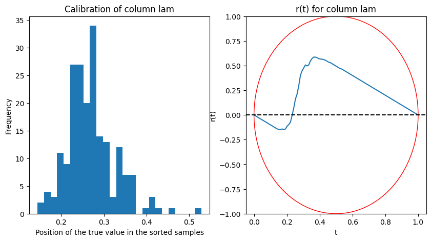

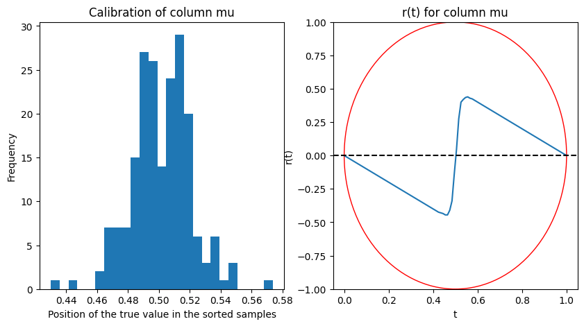

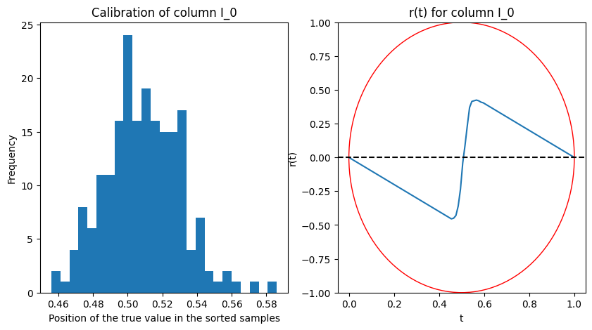

```python
evaluate_calibration_single(feature_extractor, model_realnvp, X_test, y_test, M=1000, column_names=["lam", "mu", "I_0"])
```

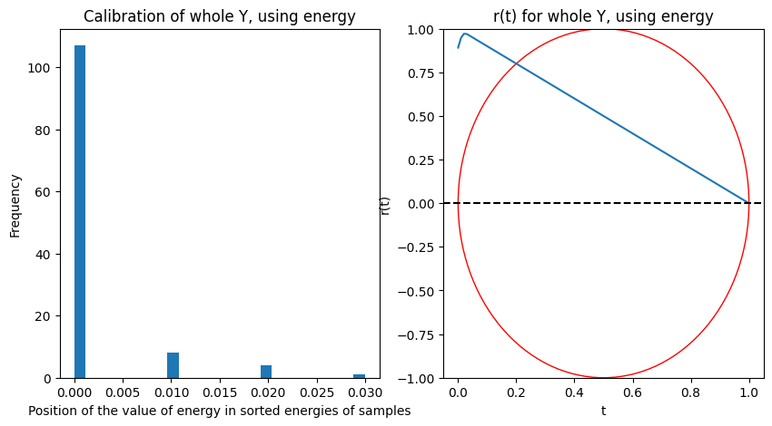

```python
evaluate_calibration_joint(feature_extractor, model_realnvp, X_test[:120], y_test[:120], M=100)
```

[output not shown]

Comment - different

- our model did not learn what it was expected to learn, therefore the results on charts showing the energy are different than the ones in the sample solution.

### 1.6

Check posterior-predictive calibration by resimulation. That is, use the Y_hat k from each of the samples ${Y_k hat ~ p(Y|h(X_i))_{k=1}}^M$ as an input to simulate_sir_simple(). Use the resulting outcomes $C_k$ to define confidence intervals for the resimulated scenarios and determine if the corresponding true outcomes $C_i$* are within these confidence intervals.

```python
def check_confidence_intervals_of_simulations(model_summary, model_realnvp, X_test, y_test, M=100, num_of_plots=3, T=100):
    """
    Args:
        model_summary (nn.Module): a model which extracts features from Y and puts as conditions to realNVP
        model_realnvp (nn.Module): a RealNVP model which returns z and log_det_jacobian_sum
        X_test (np.ndarray): the test data simulation outcome
        y_test (np.ndarray): the test data simulation parameters
        M (int): the number of samples to generate for each test set sample
        num_of_plots (int): the number of plots to show
        T (int): the length of the epidemy
    """

    y_test = torch.from_numpy(y_test).float()
    X_test = torch.from_numpy(X_test).float()
    with torch.no_grad():
        X_transformed = model_summary(X_test)
        for i, row in enumerate(X_transformed):
            if i >= num_of_plots:
                break
            row = torch.unsqueeze(row, 0).numpy()
            y_samples = model_realnvp.sample(M, row)
            y_samples = y_samples.numpy()
            C_k_simulation_outcomes = [
                simulate_sir_sample(y_samples[j][0], y_samples[j][1], y_samples[j][2], T)[1]
                for j in range(M)
            ]
            C_k_simulation_outcomes = [np.array(c).T for c in C_k_simulation_outcomes]
            C_k_simulation_outcomes = [np.concatenate([np.arange(T+1).reshape(-1, 1), c], axis=1) for c in C_k_simulation_outcomes]
            C_k_simulation_outcomes = np.concatenate(C_k_simulation_outcomes, axis=0)
            df = pd.DataFrame(C_k_simulation_outcomes, columns=["day", "S", "I", "R"])
            # for each S, I, R, plot a plot with 95% confidence interval and the real value (row)
            fig, ax = plt.subplots(1, 3, figsize=(15, 5))
            sns.lineplot(data=df, x="day", y="S", ax=ax[0])
            sns.lineplot(data=df, x="day", y="I", ax=ax[1])
            sns.lineplot(data=df, x="day", y="R", ax=ax[2])
            # plot the lineplots with the real values as well
            C_real = simulate_sir_sample(y_test[i][0], y_test[i][1], y_test[i][2], T)[1]
            C_real = np.concatenate([np.arange(T+1).reshape(-1, 1), np.array(C_real).T], axis=1)
            df_real = pd.DataFrame(C_real, columns=["day", "S", "I", "R"])
            sns.lineplot(data=df_real, x="day", y="S", ax=ax[0], color="red")
            sns.lineplot(data=df_real, x="day", y="I", ax=ax[1], color="red")
            sns.lineplot(data=df_real, x="day", y="R", ax=ax[2], color="red")
            ax[0].set_title(f"Simulation of S, real value: {y_test[i][0]:.3f}")
            ax[1].set_title(f"Simulation of I, real value: {y_test[i][1]:.3f}")
            ax[2].set_title(f"Simulation of R, real value: {y_test[i][2]:.3f}")
            ax[0].set_ylim([0, 1])
            ax[1].set_ylim([0, 1])
            ax[2].set_ylim([0, 1])
            fig.suptitle(f"Simulation vs resimulation of observation {i} from test set")
            plt.show()
```

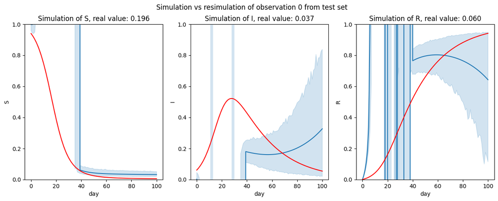

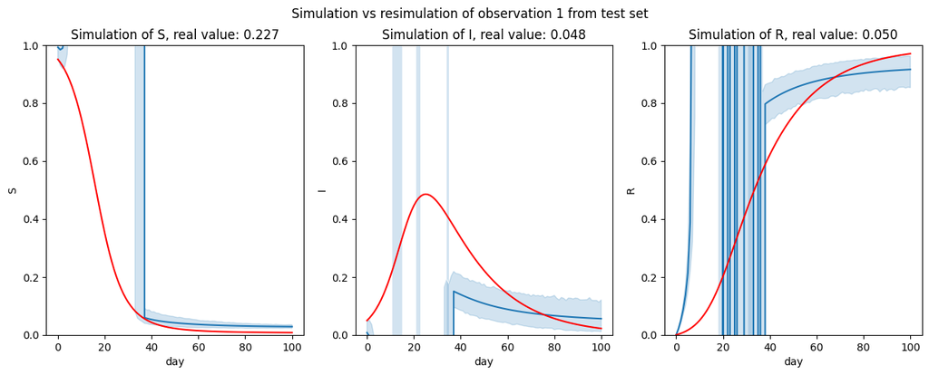

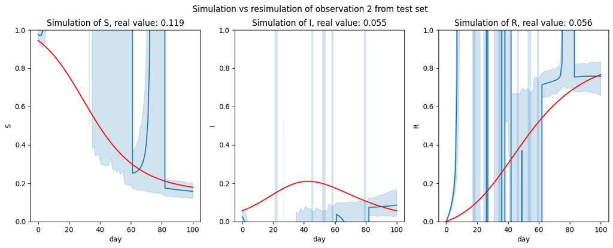

```python
check_confidence_intervals_of_simulations(feature_extractor, model_realnvp, X_test, y_test, M=100, num_of_plots=3, T=100)
```

[output not shown]

Comment - different

- while comparing those results it is more visible, that our model did not learn as expected. This can be caused by implementation differences, mentioned in 1.4.

## 2. Noisy data

Implement the new function simulate_sir_noisy(lam, mu, I_0, L, rho, sigma_2, T). We assume that the noise is multiplicative Gaussian. The new parameters $L >= 0$, $\rho <= 1$, and $\sigma^2$ represent the reporting delay, underreporting fraction, and reporting error variance respectively. Visualize the difference between noise-free outcomes X and noisy outomes X_hat to find good ranges for the new parameters and extend the prior $p^{sim}(Y)$ accordingly.

```python
def simulate_sir_noisy(lam, mu, I_0, L, rho, sigma_2, T, seed=42):
    np.random.seed(seed)
    epsilon_S=np.random.normal(rho, sigma_2)
    epsilon_R=np.random.normal(rho, sigma_2)

    S=[1 for _ in range(T+1)]
    S_prim=[1 for _ in range(T+1)]
    R=[0 for _ in range(T+1)]
    R_prim=[0 for _ in range(T+1)]
    I=[0 for _ in range(T+1)]
    I_prim=[0 for _ in range(T+1)]
    C=[0 for _ in range(T+1)]
    X=[0 for _ in range(2*T)]

    S[0]=1-I_0
    I[0]=I_0

    for i in range(T):
        S[i+1]=S[i]-lam*I[i]*S[i]
        I[i+1]=I[i]+lam*I[i]*S[i]-mu*I[i]
        R[i+1]=R[i]+mu*I[i]

    for i in range(T):
        if i>=L:
            S_prim[i+1]=(S[i-L]-lam*I[i-L]*S[i-L])*epsilon_S
            I_prim[i+1]=I[i-L]+lam*I[i-L]*S_prim[i-L]-mu*I[i-L]*epsilon_R
            R_prim[i+1]=(R[i-L]+mu*I[i-L])*epsilon_R
            X[2*i]=S_prim[i]-S_prim[i+1] #delta_S
            X[2*i+1]=R_prim[i+1]-R_prim[i] #delta_R
    C=[S_prim,I_prim,R_prim]
    return X, C
```

Comment - different

- we did not add noise to I
- we decided to generate the noise once per whole epidemy, not for each timestep separately - the way of thinking in the sample solution (e_S is a vector of epsilons) makes more sense.
- we also created noisy data based on the ones generated in the previous function, similarly to the sample solution.

As the result, the charts of the noisy data look much more different than the ones that were expected. For us, we generated the noisy data, as they were moved only slightly in various directions, but instead, we should have achieved noise as in the sample solution. This for sure had big impact on the results we got in this task.

```
Simulation results: lam: 0.18, mu: 0.05, I_0: 0.05, L: 5, rho: 0.95, sigma_2: 0.05
```

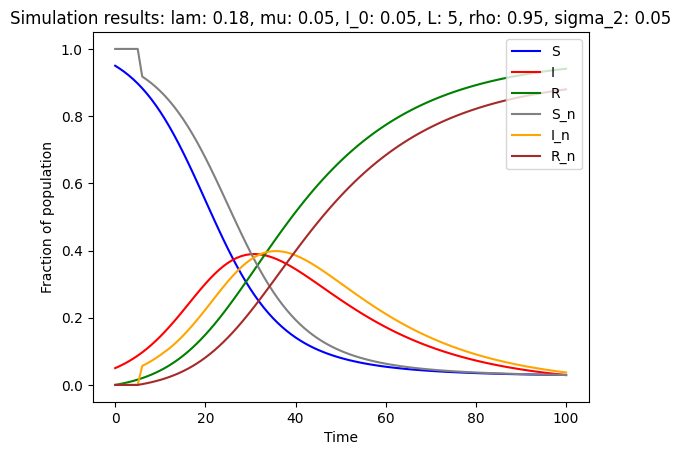

```python
"""
best result that we choose:
    lam: 0.18,
    mu: 0.05,
    I_0: 0.05,
    L: 5,
    rho: 0.95,
    sigma_2: 0.05
"""
lam = 0.18
mu = 0.05
I_0 = 0.05
L = 5
rho = 0.95
sigma_2 = 0.05
X_data, C_data = simulate_sir_sample(lam=0.18, mu=0.05, I_0=0.05, T=100)

X_noise, C_noise = simulate_sir_noisy(lam, mu, I_0, L, rho, sigma_2, 100)
plt.plot(C_data[0], c="blue", label="S")
plt.plot(C_data[1], c="red", label="I")
plt.plot(C_data[2], c="green", label="R")
plt.plot(C_noise[0], c="gray", label="S_n")
plt.plot(C_noise[1], c="orange", label="I_n")
plt.plot(C_noise[2], c="brown", label="R_n")
plt.title(f"Simulation results: lam: {lam}, mu: {mu}, I_0: {I_0}, L: {L}, rho: {rho}, sigma_2: {sigma_2}")
plt.xlabel("Time")
plt.ylabel("Fraction of population")
plt.legend(loc="upper right")
print(f"Simulation results: lam: {lam}, mu: {mu}, I_0: {I_0}, L: {L}, rho: {rho}, sigma_2: {sigma_2}")
plt.show()
```

```python
def generate_y_extended(lam=0.18, mu=0.05, I_0=0.05, L=5, rho=0.95, sigma_2=0.05):
    lam_gen=np.random.normal(lam, 0.04)
    mu_gen=np.random.normal(mu, 0.01)
    I_0_gen=np.random.normal(I_0, 0.01)
    L_gen=np.random.randint(0,10)
    rho_gen=np.random.normal(rho, 0.01)
    sigma_2_gen=np.random.normal(sigma_2, 0.01)
    y=[lam_gen,mu_gen,I_0_gen, L_gen, rho_gen, sigma_2_gen]
    return y
```

```python
y_extended=generate_y_extended()
y_extended
```

```
[0.20590754152402768,
 0.06523029856408026,
 0.047658466252766644,
 7,
 0.9476586304305081,
 0.04114769654308406]
```

### Extend networks from task 1

```python
N = 1000
# constant length of epidemy
T = 100

y_ext = np.array([generate_y_extended() for _ in range(N)])
X_ext = np.array([simulate_sir_sample(y_ext[i][0], y_ext[i][1], y_ext[i][2], T)[0] for i in range(len(y_ext))])

train_test_split = 0.8

X_train_ext = X_ext[:int(train_test_split*len(X_ext))]
X_test_ext = X_ext[int(train_test_split*len(X_ext)):]
y_train_ext = y_ext[:int(train_test_split*len(y_ext))]
y_test_ext = y_ext[int(train_test_split*len(y_ext)):]
```

```python
feedforward_model_task2 = FeedForward_Task_1_3(input_size=200, #2*T
                                         hidden_size=32,
                                         number_of_layers=2,
                                         output_size=6) # lam, mu, I_o, L, rho, sigma_2


df_ext = train_simple_feedforward(model=feedforward_model_task2,
                        X_train=X_train_ext, X_test=X_test_ext,
                        y_train=y_train_ext, y_test=y_test_ext,
                        n_epochs=20, batch_size=64)
```

[output not shown]

```python
feature_extractor_ext = FeedForward_Task_1_3_without_last_layer(feedforward_model_task2)
model_realnvp_ext = ConditionalRealNVP(input_size=6, hidden_size=64, blocks=4,
                                   condition_size=feature_extractor_ext.output_size)

df_ext_jointly = train_jointly_summary_and_inn(model_summary=feature_extractor_ext,
                              model_realnvp=model_realnvp_ext,
                              X_train = y_train_ext, # as earlier, X and y are swapped
                              X_test = y_test_ext,
                              y_train = X_train_ext,
                              y_test = X_test_ext,
                              n_epochs=100,
                              batch_size=64)
```

#### Repeat experiments from 1.3

```
Hyperparameter effect on the model MSE.
```

[figure not shown]

```python
# evaluate network sizes - hidden size, number of layers
hidden_sizes = [4, 8, 16]
numbers_of_layers = [2, 4, 8]
training_params = {'n_epochs': 20, 'batch_size': 64, 'learning_rate': 0.001}

fig, axs = plt.subplots(3, 3, figsize=(12, 12))
y_lim_max = -np.inf
for i, hidden_size in enumerate(hidden_sizes):
    for j, number_of_layers in enumerate(numbers_of_layers):

        feedforward_model_task2 = FeedForward_Task_1_3(input_size=200, #2*T
                                         hidden_size=32,
                                         number_of_layers=2,
                                         output_size=6) # lam, mu, I_o, L, rho, sigma_2


        df = train_simple_feedforward(model=feedforward_model_task2,
                                X_train=X_train_ext, X_test=X_test_ext,
                                y_train=y_train_ext, y_test=y_test_ext,
                                **training_params)

        axs[i, j].plot(df['epoch'], df['train'], label='train')
        axs[i, j].plot(df['epoch'], df['test'], label='test')
        axs[i, j].set_title(f"hidden_size={hidden_size}, number_of_layers={number_of_layers}")
        axs[i, j].legend()
        axs[i, j].set_xlabel('Epoch')
        axs[i, j].set_ylabel('MSE loss')
        y_lim_max = max(y_lim_max, max(df['train'][2:].max(), df['test'][2:].max()))
for i, hidden_size in enumerate(hidden_sizes):
    for j, number_of_layers in enumerate(numbers_of_layers):
        axs[i, j].set_ylim([0, y_lim_max*1.1])
fig.suptitle('Feedforward network sizes evaluation')
fig.tight_layout()
plt.show()
```

[output not shown]

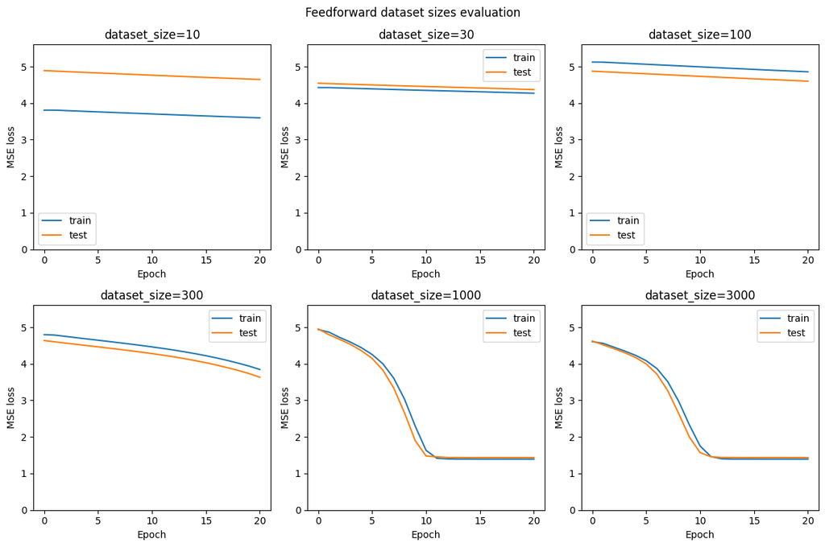

```python
# evaluate dataset sizes
dataset_sizes = [10, 30, 100, 300, 1000, 3000]
training_params = {'n_epochs': 20, 'batch_size': 64, 'learning_rate': 0.001}

fig, axs = plt.subplots(2, 3, figsize=(12, 8))
y_lim_max = -np.inf
for i, dataset_size in enumerate(dataset_sizes):
    feedforward_model_ext = FeedForward_Task_1_3(input_size=200,
                                                hidden_size=16,
                                                number_of_layers=4,
                                                output_size=6)
    df = train_simple_feedforward(model=feedforward_model_ext,
                            X_train=X_train_ext, X_test=X_test_ext, y_train=y_train_ext, y_test=y_test_ext,
                            **training_params, size_of_the_training_set=dataset_size)
    axs[i//3, i%3].plot(df['epoch'], df['train'], label='train')
    axs[i//3, i%3].plot(df['epoch'], df['test'], label='test')
    axs[i//3, i%3].set_title(f"dataset_size={dataset_size}")
    axs[i//3, i%3].set_xlabel('Epoch')
    axs[i//3, i%3].set_ylabel('MSE loss')
    axs[i//3, i%3].legend()
    y_lim_max = max(y_lim_max, max(df['train'][3:].max(), df['test'][3:].max()))
for i, dataset_size in enumerate(dataset_sizes):
    axs[i//3, i%3].set_ylim([0, y_lim_max*1.1])
fig.suptitle('Feedforward dataset sizes evaluation')
fig.tight_layout()
plt.show()
```

[output not shown]

Comment - different

- we conducted experiments, to choose best parameters for noise, and based on them conducted further experiments. The way of thinking was good.
- we investigated influence of various hyperparameters setting on the results.
- as we used the same implementation of networks, the results of the experients were also not perfect.

## 3. Model misspecification detection

We now modify the training of the networks from task 1: In addition to the NLL loss, we use an MMD loss on the output of the summary network h(X) to pull the distribution $p(h(X))$ towards a standard normal N (0, I). This allows us to recognize unusual simulation outcomes Xbad as outliers of $p(h(X_bad))$, i.e. outliers to the standard normal, for example via the standard $\chi^2$ test.

First, use test data generated by simulate_sir_simple() to make sure that the null hypothesis "All h(X) follow the desired standard normal." cannot be rejected for noise-free data at common choices of the $\chi^2$ test's p-value (e.g. 1%). Fine-tune your hyperparameters if this is not the case.

Now, use test data created with simulate_sir_noisy() and determine under which conditions the mismatch between the model assumptions (outcomes are noise-free) and the actual data (noisy outcomes) is detected by the $\chi^2$ test. Test with increasing noise levels and increasing test set size - both should facilitate the detection. Comment on your findings.

```python
# same as earlier but with added mmd

def custom_negative_log_likelihood_loss(model_outputs, log_det_jacobian_sum):
    return torch.mean(torch.sum(0.5 * torch.pow(model_outputs, 2), dim=1) - log_det_jacobian_sum)

def custom_mmd_loss(dataset_1, dataset_2, bandwidth):
    """
    Function that calculates squared MMD metric.

    Args:
        dataset_1 (torch.Tensor): array of original points.
        dataset_2 (torch.Tensor): array of reconstructed points.
        bandwidth (float): bandwidth of kernel.
    """

    M = len(dataset_1)
    part_1 = 0

    N = len(dataset_2)
    part_2 = 0

    # for i in range(N):
    #     for j in range(N):
    #         part_2 += mmd_kernel_squared_exponential(dataset_2[i], dataset_2[j], bandwidth)
    part_2 = torch.sum(torch.exp(-torch.cdist(dataset_2, dataset_2, p=2)**2 / (2 * bandwidth)))
    part_2 /= N * (N - 1)

    part_3 = 0
    # for i in range(M):
    #     for j in range(N):
    #         part_3 += mmd_kernel_squared_exponential(dataset_1[i], dataset_2[j], bandwidth)
    part_3 = torch.sum(torch.exp(-torch.cdist(dataset_1, dataset_2, p=2)**2 / (2 * bandwidth)))
    part_3 *= 2 / (M * N)

    mmd_square = part_1 + part_2 - part_3

    return mmd_square

# Non-vectorized implementation below, left for clarity

# def mmd_kernel_squared_exponential(x,y,h):
#     """
#     Function that calculates squared exponential kernel.

#     Args:
#         x (torch.Tensor): point.
#         y (torch.Tensor): point.
#         h (float): bandwidth of kernel.
#     """
#     return torch.exp(-1 * torch.norm(x - y) ** 2 / (2 * h) )

def train_jointly_summary_and_inn_with_mmd(model_summary,
                                  model_realnvp,
                                  X_train, X_test,
                                  y_train, y_test,
                                  n_epochs, batch_size,
                                  learning_rate=0.001,
                                  size_of_the_training_set=-1,
                                  loss_function=custom_negative_log_likelihood_loss,
                                  mmd_loss_function=custom_mmd_loss,
                                  bandwidth=0.3,
                                  mmd_loss_weigth=1):
    """
    Args:
        model_summary (nn.Module): a model which extracts features from Y and puts as conditions to realNVP
        model_realnvp (nn.Module): a RealNVP model which returns z and log_det_jacobian_sum
        X_train (np.ndarray): the training data                 // <- assignment 4 - Ys
        X_test (np.ndarray): the test data                      // <- assignment 4 - Ys
        y_train (np.ndarray): the training data conditions      // <- assignment 4 - Xs
        y_test (np.ndarray): the test data conditions           // <- assignment 4 - Xs
        n_epochs (int): the number of training epochs
        batch_size (int): the batch size
        learning_rate (float): the learning rate
        size_of_the_training_set (int): subset of the training set to use (default: -1, i.e. use the whole training set)
        loss_function (function): the loss function to use (default: custom_negative_log_likelihood_loss)
        mmd_loss_function (function): MMD new loss term
        bandwidth (float): bandwidth for the MMD function
        mmd_loss_weigth (float): weight for the mmd loss when adding to nnl
    """

    def compute_loss(X, y, model_summary=model_summary, model_realnvp=model_realnvp,
                     loss_function=loss_function, mmd_loss_function=mmd_loss_function,
                     bandwidth=bandwidth, mmd_loss_weigth=mmd_loss_weigth):
        y_transformed = model_summary(y)
        standard_normal = torch.randn(size=[500, y_transformed.shape[1]])
        mmd_loss_term = mmd_loss_function(y_transformed, standard_normal, bandwidth)
        z, log_det_jacobian_sum = model_realnvp(X, y_transformed)
        loss = loss_function(z, log_det_jacobian_sum)
        return loss + mmd_loss_term * mmd_loss_weigth

    optimizer = torch.optim.Adam(list(model_summary.parameters()) + list(model_realnvp.parameters()), lr=learning_rate)

    train_losses = []
    test_losses = []

    X_train = X_train[:size_of_the_training_set]
    y_train = y_train[:size_of_the_training_set]

    X_train = torch.from_numpy(X_train).float()
    y_train = torch.from_numpy(y_train).float()
    X_test = torch.from_numpy(X_test).float()
    y_test = torch.from_numpy(y_test).float()

    # loss before training
    with torch.no_grad():
        loss = compute_loss(X_train, y_train)
        train_losses.append(loss.item())
        loss = compute_loss(X_test, y_test)
        test_losses.append(loss.item())
    print(f"Epoch 0/{n_epochs}: train_loss={train_losses[-1]:.4f}, test_loss={test_losses[-1]:.4f}")

    # training
    for epoch in range(n_epochs):
        train_loss = 0
        test_loss = 0
        for i in range(0, len(X_train), batch_size):
            data = X_train[i:i+batch_size]
            y_data = y_train[i:i+batch_size]
            optimizer.zero_grad()
            loss = compute_loss(data, y_data)
            loss.backward()
            optimizer.step()
            train_loss += loss.item() * len(data)
        train_loss /= len(X_train)
        train_losses.append(train_loss)

        with torch.no_grad():
            for i in range(0, len(X_test), batch_size):
                data = X_test[i:i+batch_size]
                y_data = y_test[i:i+batch_size]
                loss = compute_loss(data, y_data)
                test_loss += loss.item() * len(data)
            test_loss /= len(X_test)
            test_losses.append(test_loss)

        if (epoch+1) % (n_epochs//10+1) == 0 or epoch == n_epochs-1:
            print(f"Epoch {epoch+1}/{n_epochs}: train_loss={train_loss:.4f}, test_loss={test_loss:.4f}")
    df = pd.DataFrame({'train': train_losses, 'test': test_losses, 'epoch': list(range(n_epochs+1))})
    return df
```

```python
from scipy.stats import chisquare

def check_chi_square_standard_normal_test(model_summary, data):
    with torch.no_grad():
        data_transformed = model_summary(torch.from_numpy(data).float())
        data_transformed = data_transformed.detach().numpy()
    p_values = chisquare(data_transformed, axis=1).pvalue
    return p_values
```

```python
def test_outliers_in_noisy(feature_extractor, noise_levels_rho, test_set_sizes, basic_parameters, p_val_threshold=0.01):
    combinations = np.zeros((len(noise_levels_rho), len(test_set_sizes)))
    for i, noise_level in enumerate(noise_levels_rho):
        for j, test_set_size in enumerate(test_set_sizes):
            X_noisy = [
                simulate_sir_noisy(
                    lam=basic_parameters["lam"],
                    mu=basic_parameters["mu"],
                    I_0=basic_parameters["I_0"],
                    L=basic_parameters["L"],
                    rho=noise_level,
                    sigma_2=basic_parameters["sigma_2"],
                    T=100,
                    seed=i
                )[0]
                for i in range(test_set_size)
            ]
            p_values = check_chi_square_standard_normal_test(feature_extractor, np.array(X_noisy))
            combinations[i, j] = np.mean(p_values<p_val_threshold)

    fig, ax = plt.subplots()
    im = ax.imshow(combinations)
    for i in range(len(noise_levels_rho)):
        for j in range(len(test_set_sizes)):
            text = ax.text(j, i, f"{combinations[i, j]:.2f}",
                        ha="center", va="center", color="w")
    plt.xticks(np.arange(len(test_set_sizes)), test_set_sizes)
    plt.yticks(np.arange(len(noise_levels_rho)), noise_levels_rho)
    plt.xlabel('Test set size')
    plt.ylabel('Noise level - mean rho of underreporting epsilons')
    plt.title('Fraction of outliers')
    cbar = ax.figure.colorbar(im, ax=ax)
    cbar.ax.set_ylabel("Fraction of outliers", rotation=-90, va="bottom")
    plt.show()
```

```python
df = train_jointly_summary_and_inn_with_mmd(model_summary=feature_extractor,
                              model_realnvp=model_realnvp,
                              X_train=y_train, # X and y swapped as earlier
                              X_test=y_test,
                              y_train=X_train,
                              y_test=X_test,
                              n_epochs=100,
                              batch_size=64,
                              bandwidth=0.5,
                              mmd_loss_weigth=1)
```

```python
print("For clean data (should mark 0% as outliers):")
p_values = check_chi_square_standard_normal_test(feature_extractor, X_train)
print(f"Percentage of observations marked as outliers: {100*np.mean(p_values<0.01)}%")
```

```
For clean data (should mark 0% as outliers):
Percentage of observations marked as outliers: 0.0%
```

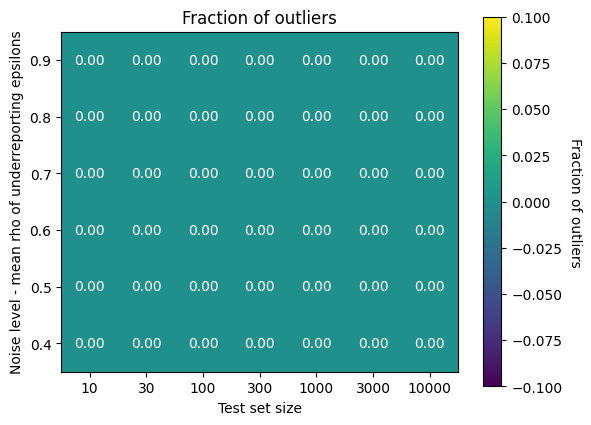

```python
noise_levels_rho = [0.9, 0.8, 0.7, 0.6, 0.5, 0.4] # different rho values being a mean of gaussian used for underreporting
test_set_sizes = [10, 30, 100, 300, 1000, 3000, 10000]

basic_parameters = {
    "lam": 0.18,
    "mu": 0.05,
    "I_0": 0.05,
    "L": 5,
    "sigma_2": 0.05
}

test_outliers_in_noisy(feature_extractor, noise_levels_rho, test_set_sizes, basic_parameters, p_val_threshold=0.01)
```

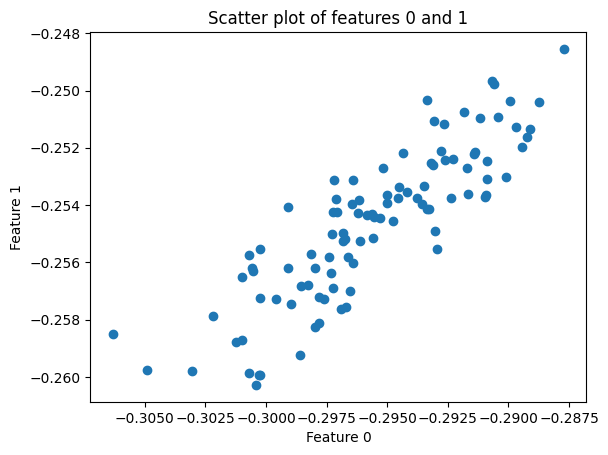

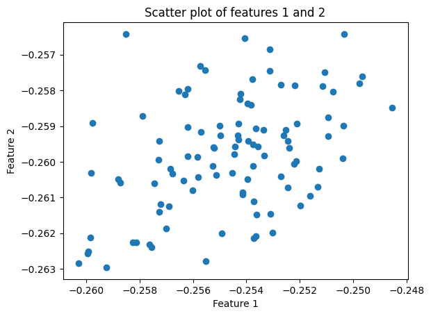

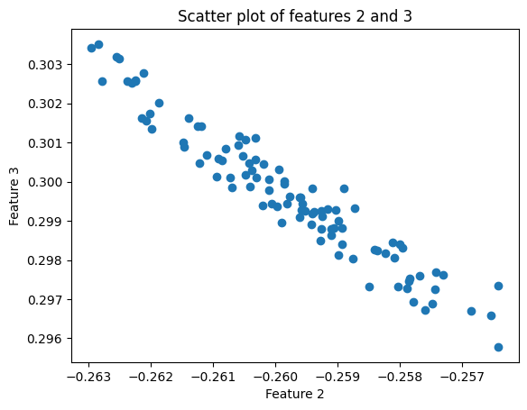

```python
# a few dimensions of a X_noisy after feature extraction - is is event gaussian?

X_noisy = [
    simulate_sir_noisy(
        lam=basic_parameters["lam"],
        mu=basic_parameters["mu"],
        I_0=basic_parameters["I_0"],
        L=basic_parameters["L"],
        rho=0.95,
        sigma_2=basic_parameters["sigma_2"],
        T=100,
        seed=i
    )[0]
    for i in range(100)
]
X_noisy = np.array(X_noisy)

with torch.no_grad():
    X_transformed = feature_extractor(torch.from_numpy(X_noisy).float())
    X_transformed = X_transformed.detach().numpy()

for i in range(3):
    fig, ax = plt.subplots()
    ax.scatter(X_transformed[:, i], X_transformed[:, i+1])
    plt.xlabel(f"Feature {i}")
    plt.ylabel(f"Feature {i+1}")
    plt.title(f"Scatter plot of features {i} and {i+1}")
    plt.show()
```

```
Comment: This does not look good. No outliers are detected. Reason for that is that the summary networks does not move the observations to standard normal but rather to a the same a single line that is close to 0 -> this might be the reason why the chi2 test does not detect any outliers.
```

Comment - different

- we implemented new loss (with added mmd) same as shows the equation in the sample solution.
- we tried conducting some experiments (results above) but as mentioned earlier, the results are not satisfying, ideas how to solve the problems can be found above.

## 4. Sensitivity analysis

Vary the variance of the prior distribution $p^{sim}(Y) (individually for each parameter) during training and make your networks hyperparameter aware. That is, pass the current settings of the(log-)variance as an additional input/condition to the networks, so that they learn the correct posterior $p(Y|h(X), Var(Y))$ for each setting of the variance vector Var(Y). In this way, the networks amortize the variability in Var(Y), and sensitivity tests become suficiently cheap to be practical (otherwise, you would have to train a new model for each setting of Var(Y), which would be prohibitively expensive). Use a test set to determine how the posterior changes under variations of Var(Y) and comment on your findings. Are there parameters which are more sensitive to the choice of prior than others? (This would mean that the data are not as informative about these parameters as we would like them to be.)

```python
def generate_y2(
                lam=0.18,
                mu=0.05,
                I_0=0.05,
                return_var=False,
                lam_var=0.04,
                mu_var=0.01,
                I_0_var=0.01):

    lam_gen=np.random.normal(lam, lam_var)
    mu_gen=np.random.normal(mu, mu_var)
    I_0_gen=np.random.normal(I_0, I_0_var)

    var=[lam_var, mu_var, I_0_var]
    y = [lam_gen,mu_gen,I_0_gen]
    if return_var:
        return y, var
    else:
        return y
```

```python
# not used but might be more interesting as there are more variances to change
def generate_y_extended2(
                         lam=0.18,
                         mu=0.05,
                         I_0=0.05,
                         L=5,
                         rho=0.95,
                         sigma_2=0.05,
                         return_var=False,
                         lam_var=0.04,
                         mu_var=0.01,
                         I_0_var=0.01,
                         L_var=10,
                         rho_var=0.01,
                         sigma_2_var=0.01):

    lam_gen=np.random.normal(lam, lam_var)
    mu_gen=np.random.normal(mu, mu_var)
    I_0_gen=np.random.normal(I_0, I_0_var)
    L_gen=np.random.randint(0,L_var)
    rho_gen=np.random.normal(rho, rho_var)
    sigma_2_gen=np.random.normal(sigma_2, sigma_2_var)

    var=[lam_var, mu_var, I_0_var, L_var, rho_var, sigma_2_var]
    y=[lam_gen,mu_gen,I_0_gen, L_gen, rho_gen, sigma_2_gen]

    if return_var:
        return y, var
    else:
        return y
```

```python
# training with added variances as new conditions to realnvp

def custom_negative_log_likelihood_loss(model_outputs, log_det_jacobian_sum):
    return torch.mean(torch.sum(0.5 * torch.pow(model_outputs, 2), dim=1) - log_det_jacobian_sum)

def train_jointly_summary_and_inn2(model_summary,
                                  model_realnvp,
                                  X_train, X_test,
                                  y_train, y_test,
                                  n_epochs, batch_size,
                                  var_train, var_test,
                                  learning_rate=0.001,
                                  size_of_the_training_set=-1,
                                  loss_function=custom_negative_log_likelihood_loss):
    """
    Args:
        model_summary (nn.Module): a model which extracts features from Y and puts as conditions to realNVP
        model_realnvp (nn.Module): a RealNVP model which returns z and log_det_jacobian_sum
        X_train (np.ndarray): the training data                 // <- assignment 4 - Ys
        X_test (np.ndarray): the test data                      // <- assignment 4 - Ys
        y_train (np.ndarray): the training data conditions      // <- assignment 4 - Xs
        y_test (np.ndarray): the test data conditions           // <- assignment 4 - Xs
        n_epochs (int): the number of training epochs
        batch_size (int): the batch size
        learning_rate (float): the learning rate
        size_of_the_training_set (int): subset of the training set to use (default: -1, i.e. use the whole training set)
        loss_function (function): the loss function to use (default: custom_negative_log_likelihood_loss)
    """

    def compute_loss2(X, y, var, model_summary=model_summary, model_realnvp=model_realnvp,
                     loss_function=loss_function):
        y_transformed = model_summary(y)
        y_transformed=torch.concat([y_transformed,var], axis=1)
        z, log_det_jacobian_sum = model_realnvp(X, y_transformed)
        loss = loss_function(z, log_det_jacobian_sum)
        return loss

    optimizer = torch.optim.Adam(list(model_summary.parameters()) + list(model_realnvp.parameters()), lr=learning_rate)

    train_losses = []
    test_losses = []

    X_train = X_train[:size_of_the_training_set]
    y_train = y_train[:size_of_the_training_set]
    var_train = var_train[:size_of_the_training_set]

    X_train = torch.from_numpy(X_train).float()
    y_train = torch.from_numpy(y_train).float()
    X_test = torch.from_numpy(X_test).float()
    y_test = torch.from_numpy(y_test).float()
    var_train = torch.from_numpy(var_train).float()
    var_test = torch.from_numpy(var_test).float()

    # loss before training
    with torch.no_grad():
        loss = compute_loss2(X_train, y_train, var_train)
        train_losses.append(loss.item())
        loss = compute_loss2(X_test, y_test, var_test)
        test_losses.append(loss.item())
    print(f"Epoch 0/{n_epochs}: train_loss={train_losses[-1]:.4f}, test_loss={test_losses[-1]:.4f}")

    # training
    for epoch in range(n_epochs):
        train_loss = 0
        test_loss = 0
        for i in range(0, len(X_train), batch_size):
            data = X_train[i:i+batch_size]
            y_data = y_train[i:i+batch_size]
            var_data=var_train[i:i+batch_size]
            optimizer.zero_grad()
            loss = compute_loss2(data, y_data, var_data)
            loss.backward()
            optimizer.step()
            train_loss += loss.item() * len(data)
        train_loss /= len(X_train)
        train_losses.append(train_loss)

        with torch.no_grad():
            for i in range(0, len(X_test), batch_size):
                data = X_test[i:i+batch_size]
                y_data = y_test[i:i+batch_size]
                var_data=var_test[i:i+batch_size]
                loss = compute_loss2(data, y_data, var_data)
                test_loss += loss.item() * len(data)
            test_loss /= len(X_test)
            test_losses.append(test_loss)

        if (epoch+1) % (n_epochs//10+1) == 0 or epoch == n_epochs-1:
            print(f"Epoch {epoch+1}/{n_epochs}: train_loss={train_loss:.4f}, test_loss={test_loss:.4f}")
    df = pd.DataFrame({'train': train_losses, 'test': test_losses, 'epoch': list(range(n_epochs+1))})
    return df
```

```
Generating test and train data using the simpler model without noise
```

```python
N=1000 # observations
T=100 # time steps

# create a dataset with Ys created with 4 different variances
# each time, only one of the variances is different from the basic one
# lastly, we shuffle the dataset to have some of each variance in train and test
y_list=[0 for _ in range(N)]
var_list=[0 for _ in range(N)]
for i in range(N):
    if i<N/4:
        lam_var=0.04
        mu_var=0.01
        I_0_var=0.01
    elif N/4<=i<N/2:
        lam_var=np.random.normal(0.04, 0.005)
        mu_var=0.01
        I_0_var=0.01
    elif N/2<=i<3*N/4:
        lam_var=0.04
        mu_var=np.random.normal(0.01, 0.001)
        I_0_var=0.01
    else:
        lam_var=0.04
        mu_var=0.01
        I_0_var=np.random.normal(0.01, 0.001)
    y_list[i], var_list[i]=generate_y2(return_var=True, lam_var=lam_var, mu_var=mu_var, I_0_var=I_0_var)
y_pre=np.array(y_list)
var_pre=np.array(var_list)
X_pre = np.array([simulate_sir_sample(y_pre[i][0], y_pre[i][1], y_pre[i][2], T)[0] for i in range(len(y_pre))])

permutation_indices = np.random.permutation(len(var_pre))

X = X_pre[permutation_indices]
y = y_pre[permutation_indices]
var = var_pre[permutation_indices]

train_test_split = 0.8

X_train = X[:int(train_test_split*len(X))]
X_test = X[int(train_test_split*len(X)):]
y_train = y[:int(train_test_split*len(y))]
y_test = y[int(train_test_split*len(y)):]
var_train = var[:int(train_test_split*len(var))]
var_test = var[int(train_test_split*len(var)):]
```

```
Pre-training feedforward feature extractor
```

```python
feedforward_model_task4 = FeedForward_Task_1_3(input_size=200, #2*T
                                         hidden_size=32,
                                         number_of_layers=2,
                                         output_size=3) # lam, mu, I_o


df4 = train_simple_feedforward(model=feedforward_model_task4,
                        X_train=X_train, X_test=X_test,
                        y_train=y_train, y_test=y_test,
                        n_epochs=20, batch_size=64)


feature_extractor_4 = FeedForward_Task_1_3_without_last_layer(feedforward_model_task4)
```

```
Joint training of summary network and conditional normalizing flow.
```

```python
new_condition_size = feature_extractor_4.output_size + var_train.shape[1]

model_realnvp_4 = ConditionalRealNVP(input_size=3, hidden_size=64, blocks=4,
                                   condition_size=int(new_condition_size))

df = train_jointly_summary_and_inn2(model_summary=feature_extractor_4,
                              model_realnvp=model_realnvp_4,
                              X_train = y_train, # swapped X and y
                              X_test = y_test,
                              y_train = X_train,
                              y_test = X_test,
                              var_train=var_train,
                              var_test=var_test,
                              n_epochs=100,
                              batch_size=64)
```

```python
var_pre
```

```
array([[0.04      , 0.01      , 0.01      ],
       [0.04      , 0.01      , 0.01      ],
       [0.04      , 0.01      , 0.01      ],
       ...,
       [0.04      , 0.01      , 0.00853889],
       [0.04      , 0.01      , 0.0089178 ],
       [0.04      , 0.01      , 0.00967705]])
```

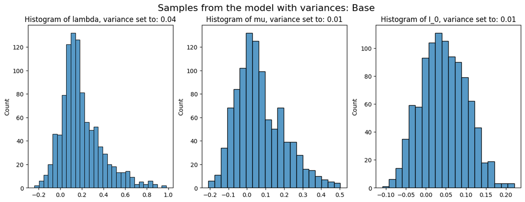

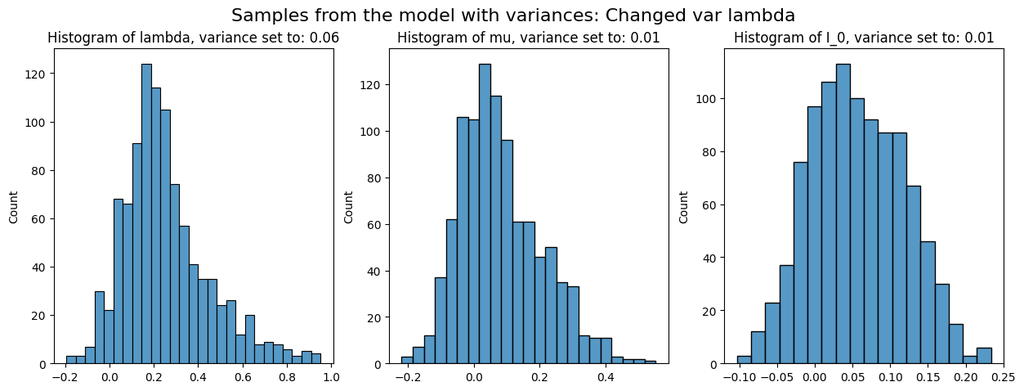

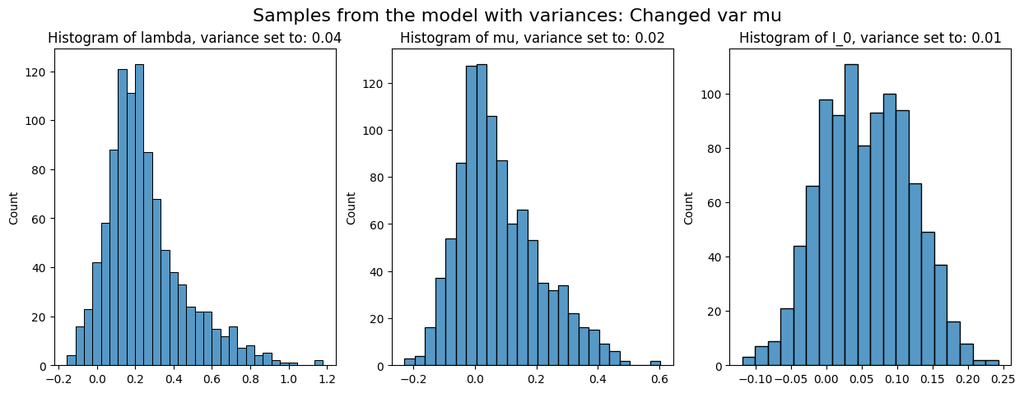

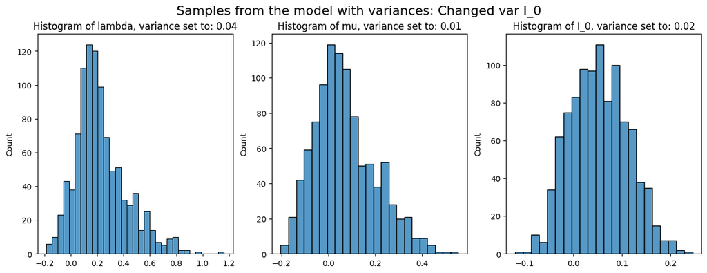

```python
# for each variance combination (there are for), take a sample from test set and generate 1000 samples
# then, plot histograms of each of the 3 features

y_base = np.array([generate_y2(lam_var=0.04, mu_var=0.01, I_0_var=0.01)]) # defaults
y_changed_var_lambda = np.array([generate_y2(lam_var=0.06)])
y_changed_var_mu = np.array([generate_y2(mu_var=0.02)])
y_changed_var_I_0 = np.array([generate_y2(I_0_var=0.02)])

ys = {
    'Base' : (y_base, [0.04, 0.01, 0.01]),
    'Changed var lambda' : (y_changed_var_lambda, [0.06, 0.01, 0.01]),
    'Changed var mu' : (y_changed_var_mu, [0.04, 0.02, 0.01]),
    'Changed var I_0' : (y_changed_var_I_0, [0.04, 0.01, 0.02])
}

for key, (y, y_vars) in ys.items():
    X = np.array([simulate_sir_sample(y[0][0], y[0][1], y[0][2], T)[0]]) # sample observation from this y
    with torch.no_grad():
        X_transformed = feature_extractor_4(torch.from_numpy(X).float())

    # sample 100 ys from the model
    y_samples = model_realnvp_4.sample(1000, torch.cat([X_transformed, torch.Tensor(y).float()], axis=1).detach().numpy()).detach().numpy()
    # plot histograms of each of the 3 features of y_samples
    fig, ax = plt.subplots(1, 3, figsize=(15, 5))
    sns.histplot(y_samples[:, 0], ax=ax[0])
    sns.histplot(y_samples[:, 1], ax=ax[1])
    sns.histplot(y_samples[:, 2], ax=ax[2])
    ax[0].set_title(f"Histogram of lambda, variance set to: {y_vars[0]:.2f}")
    ax[1].set_title(f"Histogram of mu, variance set to: {y_vars[1]:.2f}")
    ax[2].set_title(f"Histogram of I_0, variance set to: {y_vars[2]:.2f}")
    fig.suptitle(f"Samples from the model with variances: {key}", fontsize=16)
    plt.show()
```

```
Comment: Not much differences are present between distributions of Ys generated from the posterior when sampled with slightly different variances as conditions. This might mean that the model is not that sensitive to the choice of parameters and that the data is more informative about the parameters (which would be good).
```

Comment - different

- we conducted similar experiments as in the sample solution. However, for us, the changes were less visible and therefore, we might think, that our model was less sensitive to slight differences in parameters values, which is good.